# Candle Stick Pattern Recognition

Ko Chiu Yu

2019-04-19

How can you recongize candle stick patterns? This R package allows you to recognized them based on formulas.

## Installation

To install this package, it is the easist to use devtools:

```r
#install.packages("devtools")
library(devtools)
```

Then we can use the `install_github` to get the package directly:

```r
#install_github("kochiuyu/CandleStickPattern")
library(CandleStickPattern)
```

To start, let us review the basic of candle stick.

# Candle Stick Basics

Candle Stick visuall display the OHLC data. OHLC means open (Op), high (Hi), low (Li) and close (Cl) prices.

First, the rectangle body tells close and open prices. The color of the rectangle would tell whether the higher end of body is open or close price:

- Bullish Candle: close > open (green or white)
- Bearish Candle: close < open (red or black)

Two ends tells high and low prices. The line between two ends to the candle are called shadow:

- Upper Shadow: high and real body
- Lower Shadow: low and real body

# Lengths

Size of candle body (rectangle) and the lenght of two shadows are important for the pattern recognition. We first define them first:

- Upper shadow length: $US(t)=Hi(t)-\max\{Op(t),Cl(t)\}$
- Lower shadow length: $LS(t)=\min\{Op(t),Cl(t)\}-Lo(t)$
- Whole candle length: $WC(t)=Hi(t)-Lo(t)$
- Body length: $BL(t)= |Op(t)-Cl(t)|$

## Size of body length

Compare with whole candle length:

- small body: $\delta WC(t) > BL(t)$ for small $\delta=0.1$
- large body: $\delta WC(t) < BL(t)$ for large $\delta=0.9$

## Size of shadow

Compare with whole candle length:

- short upper shadow: $\delta WC(t) > US(t)$ for small $\delta=0.1$
- long upper shadow: $\delta WC(t) < US(t)$ for large $\delta=0.9$

## Size of candle length

Compare with historical whole candle lengths:

- small body: $WC(t) < \delta \times median\{WC(t-1),...,WC(t-n-1)\}$ for parameter $\delta=1$
- large body: $WC(t) > \delta \times median\{WC(t-1),...,WC(t-n-1)\}$ for parameter $\delta=1$

Similar ideas can be extended to body length and shadow sizes.

## Price Movement

Daily

- Up: $U(t)=1 \text{ if } Cl(t)>Op(t)$ and 0 otherwise
- Down: $D(t)=1 \text{ if } Cl(t)<Op(t)$ and 0 otherwise

Inter-day Gap

# Doji (1-day pattern)

## Doji (Japanese: Crux)

Indecision signal: up and down forces are balanced

1. long candle stick (High >> Low)
2. narrow real body (Close ~ Open)

Let see an example:

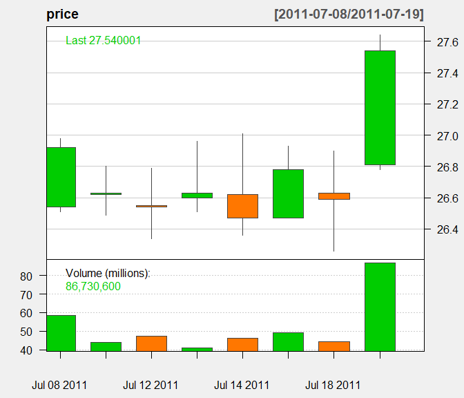

```r
price <- MSFT['2011-07-08/2011-07-19']
candleChart(price,theme='white')
```

Now let us see whether our code can recongize it. The synatx is `doji()`:

```r
doji(price)
```

```
#>             doji
#> 2011-07-08 FALSE
#> 2011-07-11  TRUE
#> 2011-07-12  TRUE
#> 2011-07-13  TRUE
#> 2011-07-14 FALSE
#> 2011-07-15 FALSE
#> 2011-07-18  TRUE
#> 2011-07-19 FALSE
```

## Dragonfly Doji

Bullish signal: resist downward pressure

1. long candle stick + narrow real body (Doji)
2. short upper shadow (High ~ Close ~ Open)

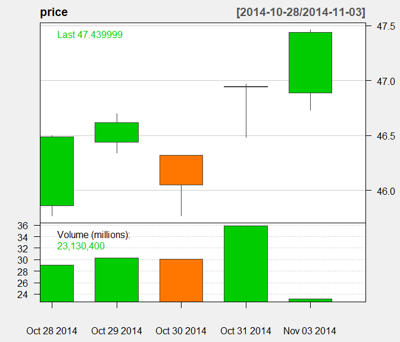

```r
price <- MSFT['2014-10-28/2014-11-03']
candleChart(price,theme='white')
```

Now let us see whether our code can recongize it. The synatx is `dragonfly.doji()`:

```r
dragonfly.doji(price)
```

```
#>            dragonfly doji
#> 2014-10-28          FALSE
#> 2014-10-29          FALSE
#> 2014-10-30          FALSE
#> 2014-10-31           TRUE
#> 2014-11-03          FALSE
```

## Gravestone Doji

1. Doji (long candle stick + narrow real body)
2. Low ~ Close ~ Open (short lower shadow)

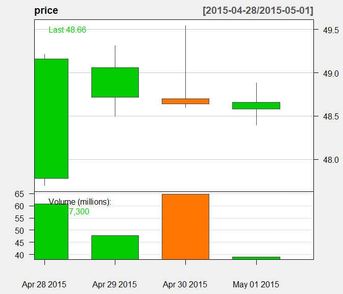

```r
price <-MSFT['2015-04-28/2015-05-01']
candleChart(price, theme='white')
```

Now let us see whether our code can recongize it. The synatx is `graveston.doji()`:

```r
gravestone.doji(price)
```

```
#>            gravestone.doji
#> 2015-04-28           FALSE
#> 2015-04-29           FALSE
#> 2015-04-30            TRUE
#> 2015-05-01           FALSE
```

# Harmers (2-day pattern)

## Harmer and Hang Man

Reversal signal:

1. Short upper shadow
2. Long lower shadow
- Harmer: Bullish signal in a downward trend
- Hang Man: Bearish signal in a upward trend

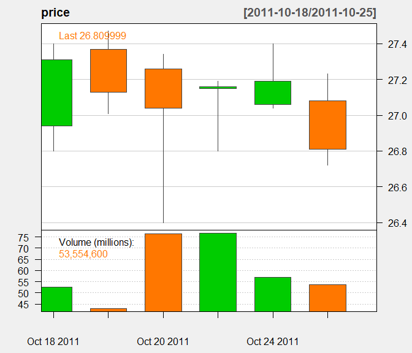

```r
price <- MSFT['2011-10-18/2011-10-25']
candleChart(price, theme='white')
```

Now let us see whether our code can recongize it. The synatx is `hammer()`:

```r
hammer(price)
```

```
#>            hammer
#> 2011-10-18  FALSE
#> 2011-10-19  FALSE
#> 2011-10-20  FALSE
#> 2011-10-21   TRUE
#> 2011-10-24  FALSE
#> 2011-10-25  FALSE
```

## Inverted Harmer and Shooting Stars

Reversal signal:

1. Long upper shadow
2. Short lower shadow
- Inverted Harmer: Bullish signal in a downward trend
- Shooting Stars: Bearish signal in a upward trend

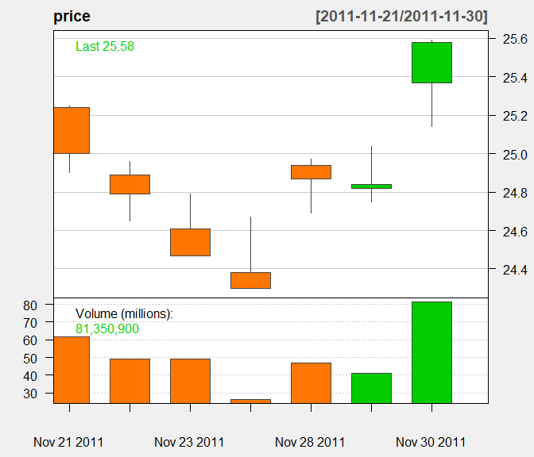

```r
price <- MSFT['2011-11-20/2011-11-30']
candleChart(price, theme='white')
```

Now let us see whether our code can recongize it. The synatx is `inverted.hammer()`:

```r
inverted.hammer(price)
```

```
#>            inverted harmer
#> 2011-11-21           FALSE
#> 2011-11-22           FALSE
#> 2011-11-23           FALSE
#> 2011-11-25            TRUE
#> 2011-11-28           FALSE
#> 2011-11-29           FALSE
#> 2011-11-30           FALSE
```

# Engulfing Patterns (2-day pattern)

## Bullish Engulfing

Bullish signal as bullish force dominates:

1. Bearish Candle on Day 1
2. Bullish Candle on Day 2
3. Real body of Day 1 Candle within that of Day 2.

## Example

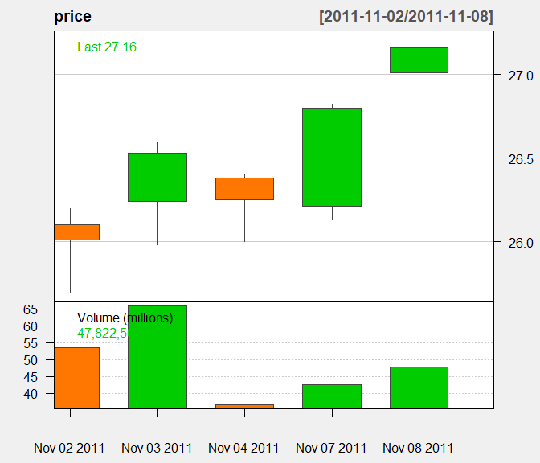

```r
price <- MSFT['2011-11-02/2011-11-08']
candleChart(price, theme='white')
```

Now let us see whether our code can recongize it. The synatx is `bullish.engulf()`:

```r
bullish.engulf(price)
```

```
#>            bullish engulfing
#> 2011-11-02             FALSE
#> 2011-11-03             FALSE
#> 2011-11-04             FALSE
#> 2011-11-07              TRUE
#> 2011-11-08             FALSE
```

## Bearish Enguling

Bearish signal as bearish force dominates:

1. Bullish Candle on Day 1
2. Bearish Candle on Day 2
3. Real body of Day 1 Candle within that of Day 2.

## Example

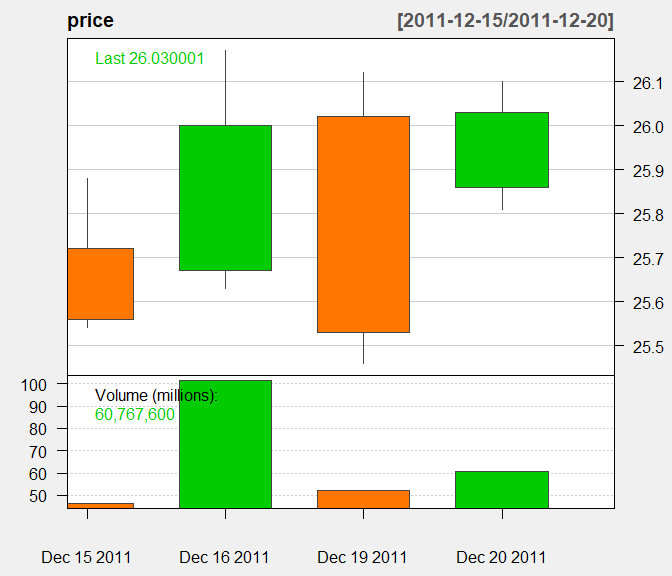

```r
price <-MSFT['2011-12-15/2011-12-20']
candleChart(price, theme='white')
```

Now let us see whether our code can recongize it. The synatx is `bearish.engulf()`:

```r
bearish.engulf(price)
```

```
#>            bearish engulfing
#> 2011-12-15                NA
#> 2011-12-16             FALSE
#> 2011-12-19              TRUE
#> 2011-12-20             FALSE
```

# Harami (Pregnant:2-day pattern)

## Bullish Harami

Bullish signal as bullish force fights back:

1. Large Bearish Candle on Day 1
2. Small Bullish Candle on Day 2
3. Real body of Day 2 Candle within that of Day 1.

## Example

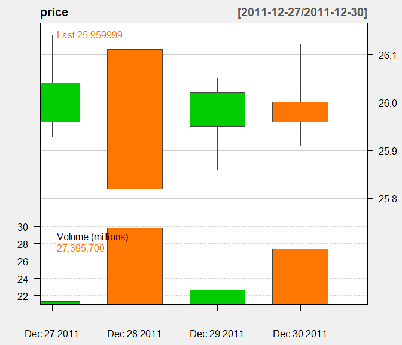

```r
price <- MSFT['2011-12-27/2011-12-30']
candleChart(price, theme='white')
```

Now let us see whether our code can recongize it. The synatx is `bullish.harami()`:

```r
bullish.harami(price)
```

```
#>            bullish harami
#> 2011-12-27             NA
#> 2011-12-28          FALSE
#> 2011-12-29           TRUE
#> 2011-12-30          FALSE
```

## Bearish Harami

Bearish signal as bearish force fights back

1. Large Bullish Candle on Day 1
2. Small Bearish Candle on Day 2
3. Real body of Day 2 Candle within that of Day 1.

## Example

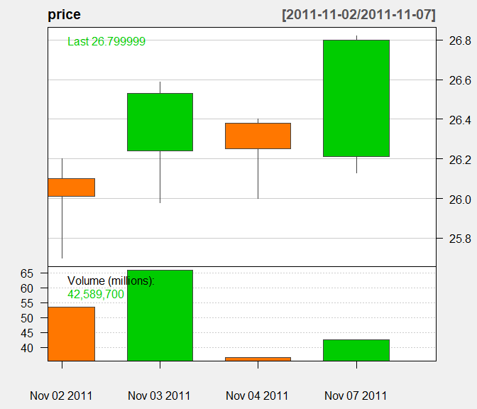

```r
price <- MSFT['2011-11-02/2011-11-07']
candleChart(price, theme='white')
```

Now let us see whether our code can recongize it. The synatx is `bearish.harami()`:

```r
bearish.harami(price)
```

```
#>            bearish harami
#> 2011-11-02             NA
#> 2011-11-03          FALSE
#> 2011-11-04           TRUE
#> 2011-11-07          FALSE
```

# Median Reversal (2-day pattern)

## Piercing Line

Bullish signal

1. Bearish candle on day 1
2. Bullish candle on day 2
3. Close on day 2 > mid point of day 1 body

## Example

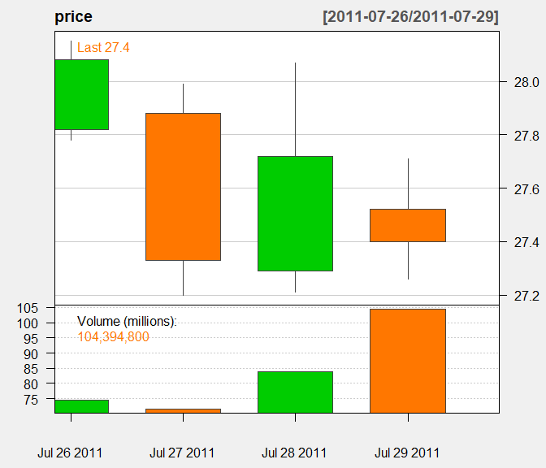

```r
price <-MSFT['2011-07-26/2011-07-30']
candleChart(price, theme='white')
```

Now let us see whether our code can recongize it. The synatx is `piercing.line()`:

```r
piercing.line(price)
```

```
#>            piercing line
#> 2011-07-26            NA
#> 2011-07-27         FALSE
#> 2011-07-28          TRUE
#> 2011-07-29         FALSE
```

## Dark cloud cover

1. Bullish candle on day 1
2. Bearish candle on day 2
3. Close on day 2 < mid point of day 1 body

## Example

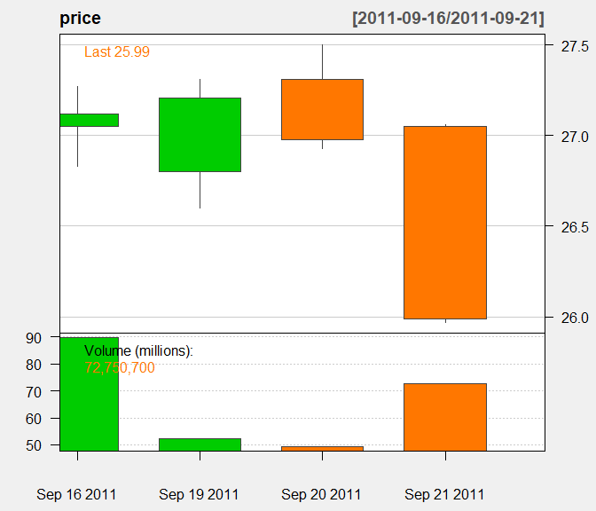

```r
price <- MSFT['2011-09-16/2011-09-21']
candleChart(price, theme='white')
```

Now let us see whether our code can recongize it. The synatx is `dark.cloud.cover()`:

```r
dark.cloud.cover(price)
```

```
#>            dark cloud cover
#> 2011-09-16            FALSE
#> 2011-09-19            FALSE
#> 2011-09-20             TRUE
#> 2011-09-21            FALSE
```

# Two in a row

## Kicking up

Bullish signal:

1. bearish candle on day 1
2. bullish candle on day 2
3. gap up between day 1 and day 2

## Example

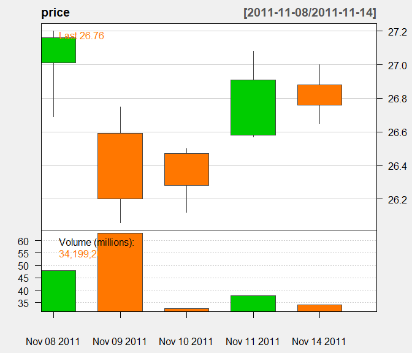

```r
price <-MSFT['2011-11-08/2011-11-14']
candleChart(price, theme='white')
```

Now let us see whether our code can recongize it. The synatx is `kick.up()`:

```r
kick.up(price)
```

```
#>            kick up
#> 2011-11-08      NA
#> 2011-11-09   FALSE
#> 2011-11-10   FALSE
#> 2011-11-11    TRUE
#> 2011-11-14   FALSE
```

## Kicking Down

Bearish signal:

1. bullish candle on day 1
2. bearish candle on day 2
3. gap down between day 1 and day 2

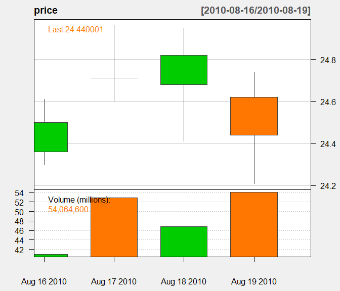

```r
price <- MSFT['2010-08-16/2010-08-19']
candleChart(price, theme='white')
```

Now let us see whether our code can recongize it. The synatx is `kick.down()`:

```r
kick.down(price)
```

```
#>            kick down
#> 2010-08-16     FALSE
#> 2010-08-17     FALSE
#> 2010-08-18     FALSE
#> 2010-08-19      TRUE
```

# Three-in-a-row (3-day pattern)

## Three white solders

Bullish signal:

1. Large bullish candles for 3 days
2. Open prices are rising for 3 days
3. Close prices are rising for 3 days

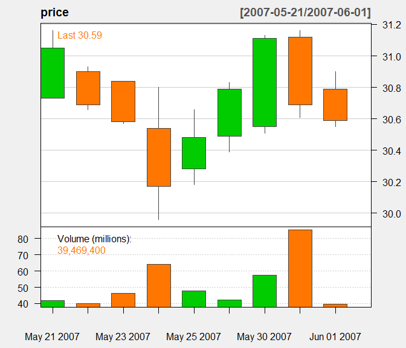

```r
price <-MSFT['2007-05-20/2007-06-01']
candleChart(price, theme='white')
```

Now let us see whether our code can recongize it. The synatx is `three.white.soldiers()`:

```r
TWS <- three.white.soldiers(MSFT)
TWS['2007-05-20/2007-06-01']
```

```
#>            three white soliders
#> 2007-05-21                FALSE
#> 2007-05-22                FALSE
#> 2007-05-23                FALSE
#> 2007-05-24                FALSE
#> 2007-05-25                FALSE
#> 2007-05-29                FALSE
#> 2007-05-30                 TRUE
#> 2007-05-31                FALSE
#> 2007-06-01                FALSE
```

## Three Black Crows

Bearish signal:

1. Large bearish candles for 3 days
2. Open prices are dropping for 3 days
3. Close prices are dropping for 3 days

## Example

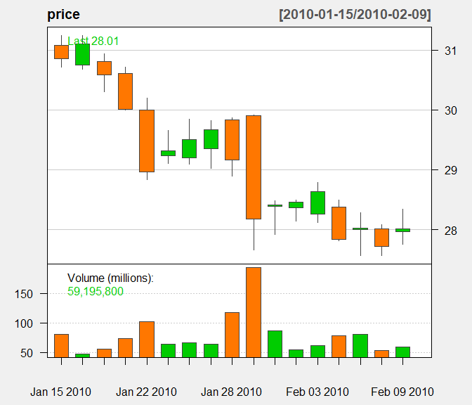

```r
price <-MSFT['2010-01-15/2010-02-09']
candleChart(price, theme='white')
```

Now let us see whether our code can recongize it. The synatx is `three.black.crows()`:

```r
TBC <- three.black.crows(MSFT)
TBC['2007-05-20/2007-06-01']
```

[output not shown]

# Star (3-day pattern)

## Morning star

Bullish signal:

1. Large bearish candle on day 1
2. Small candle (or doji) on day 2
3. Large bullish candle on day 3
4. Gap down between day 1 and day 2
5. Gap up between day 2 and day 3

## Example

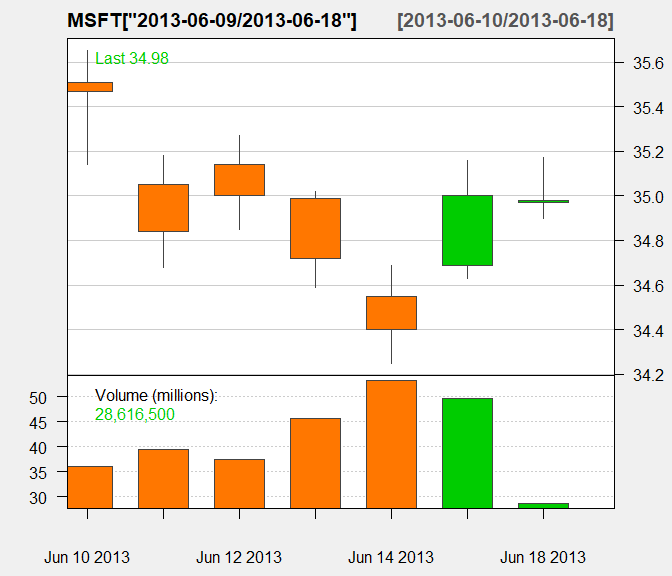

```r
price <- MSFT['2013-06-09/2013-06-18']
candleChart(MSFT['2013-06-09/2013-06-18'], theme='white')
```

Now let us see whether our code can recongize it. The synatx is `morning.star()`:

```r
MS <- morning.star(MSFT)
MS['2013-06-09/2013-06-18']
```

```
#>            morning star
#> 2013-06-10        FALSE
#> 2013-06-11        FALSE
#> 2013-06-12        FALSE
#> 2013-06-13        FALSE
#> 2013-06-14        FALSE
#> 2013-06-17         TRUE
#> 2013-06-18        FALSE
```

## Evening Star

Bearish Signal:

1. Large **bullish** candle on day 1
2. Small candle (or doji) on day 2
3. Large **bearish** candle on day 3
4. **Gap up** between day 1 and day 2
5. **Gap down** between day 2 and day 3

## Example

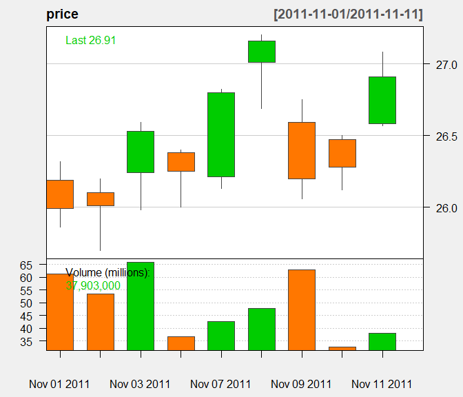

```r
price <-MSFT['2011-11-01/2011-11-11']
candleChart(price, theme='white')
```

Now let us see whether our code can recongize it. The synatx is `evening.star()`:

```r
ES <- evening.star(MSFT)
ES['2011-11-01/2011-11-11']
```

```
#>            evening star
#> 2011-11-01        FALSE
#> 2011-11-02        FALSE
#> 2011-11-03        FALSE
#> 2011-11-04        FALSE
#> 2011-11-07        FALSE
#> 2011-11-08        FALSE
#> 2011-11-09         TRUE
#> 2011-11-10        FALSE
#> 2011-11-11        FALSE
```

# Three Methods (5-day pattern)

## Rising Three

Bullish signal:

1. Large bullish candle on day 1
2. (small) bearish candles for next 3 days
3. Large bullish candle on day 5
4. Day 1 low is lowest
5. Day 5 high is highest

## Example

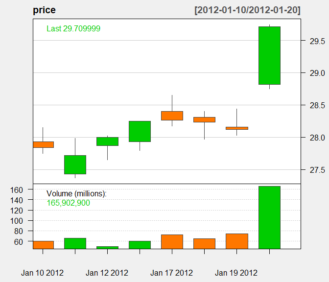

```r
price <-MSFT['2012-01-10/2012-01-22']
candleChart(price, theme='white')
```

Now let us see whether our code can recongize it. The synatx is `rising.three()`:

```r
RT <- rising.three(MSFT)
RT['2012-01-10/2012-01-22']
```

```
#>            rising three
#> 2012-01-10        FALSE
#> 2012-01-11        FALSE
#> 2012-01-12        FALSE
#> 2012-01-13        FALSE
#> 2012-01-17        FALSE
#> 2012-01-18        FALSE
#> 2012-01-19        FALSE
#> 2012-01-20         TRUE
```

## Falling three

Bearish signal:

1. Large bearish candle on day 1
2. (small) bullish candles for next 3 days
3. Large bearish candle on day 5
4. Day 1 high is the highest
5. Day 5 low is the lowest

The synatx is `falling.three()`.

# Appendix: Trend

This part is less related to candle stick pattern but nevertheless sometimes candle chart pattern requires the usage of trend. This package provides a very simple way to determine trend using exponential moving average (EMA.)

We compare a short-run EMA with a long-run EMA to determine trend.

## Up trend

If the short-run EMA is bigger than long-run EMA, then it is upward trend.

The synatx is `up.trend(price, S, L, delta)` where `S` and `L` are the number of periods for short-run and long-run EMA, and `delta` is sensitivity parameter.

## Down trend

The synatx is `down.trend(price, S, L, delta)` where `S` and `L` are the number of periods for short-run and long-run EMA, and `delta` is sensitivity parameter.